# ANALYSIS OF CRIME IN THE CITY OF BOSTON

[figure not shown]

1) Where do incidents happen in Boston?

2) Who committed those incidents?

3) When do these incidents happen?

## Where do incidents happen in Boston?

While Roxbury is the district where most incidents are committed, a central district as Downtown is by far the district where most incidents are committed per person. This is notably due to the fact that it is a business district with few residents. Note that Charlestown district and Downtown share the same police station in the map below

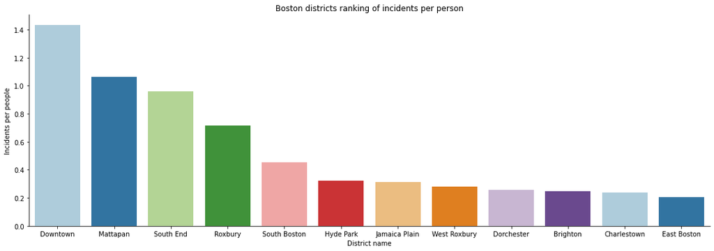

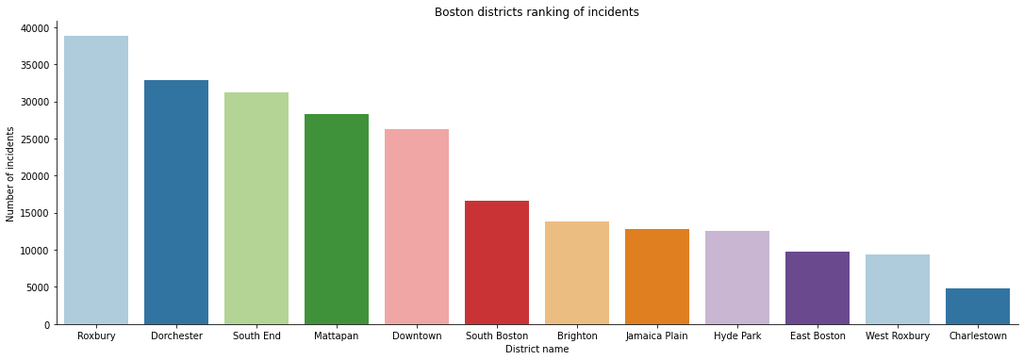

Map of Boston with incidents and police stations

```python
m
```

[interactive chart not shown]

```python
distance_df
```

| District | Average distance to incident (km) |
| --- | --- |
| West Roxbury | 2.171069 |
| Charlestown | 1.938616 |
| Hyde Park | 1.723105 |
| Roxbury | 1.463647 |
| South Boston | 1.411748 |
| Dorchester | 1.367756 |
| South End | 1.325932 |
| Brighton | 1.313056 |
| Mattapan | 1.310414 |
| Jamaica Plain | 1.264734 |
| East Boston | 1.203011 |
| Downtown | 0.854843 |

We could contemplate to create new police stations closer to where incidents are committed, notably in the districts of Charlestown and West Roxbury

## Who committed those incidents?

```python
fig.show()
```

[interactive chart not shown]

From there we see that districts with low per capita income, and few residents having moved in from abroad or from another US state less than one year ago, are districts where more incidents happen

## When do these incidents happen?

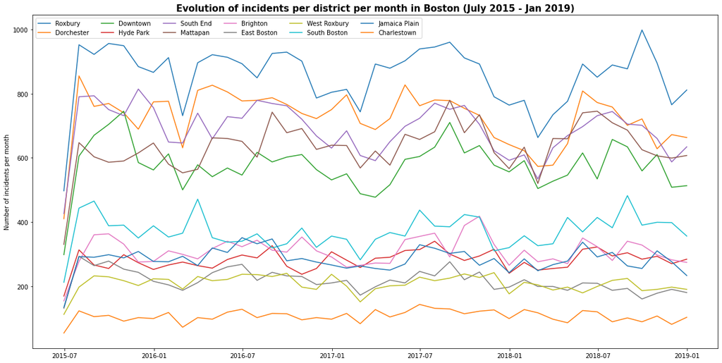

Over the last few years we do not note major increasing or decreasing trends in incidents committed, while we can easily distinguish two sets of districts: high-criminality districts (Roxbury, Dorchester, South End, Downtown and Mattapan) and low-criminality districts (the others)

**Acting on socio-economic inequalities as well as locating police stations closer to where crimes are committed could help Boston PD reduce crime in the city**

Thank you !

*The Locomotive consulting firm* ! *Sacha LEHMANN*

[figure not shown]